# p8130_hw4

Catherine

11/11/2018

### Problem 2

For this problem, you will be using data ‘HeartDisease.csv’. The investigator is mainly interested if there is an association between ‘total cost’ (in dollars) of patients diagnosed with heart disease and the ‘number of emergency room (ER) visits’. Further, the model will need to be adjusted for other factors, including ‘age’, ‘gender’, ‘number of complications’ that arose during treatment, and ‘duration of treatment condition’.

#### a) Provide a short description of the data set: what is the main outcome, main predictor and other important covariates. Also, generate appropriate descriptive statistics for all variables of interest (continuous and categorical) – no test required.

```r
hd_data = read.csv("./data/HeartDisease.csv")
hd_gender = hd_data %>%
  select(gender)
hd_num = hd_data %>%
  select(-gender)
```

**Description** :

There are 788 observations and 10 variables in the dataset.

Variables include: id, totalcost, age, gender, interventions, drugs, ERvisits, complications, comorbidities, duration

- `id` : subscribers identification number from 1-788
- `totalcost`: total cost (in dollars) of subscribers diagnosed with heart disease
- `age` : the age of subscribers
- `gender` : the gender of subscribers, 1 if male, 0 otherwise
- `intervetions` : number of interventions carried out
- `drugs` : number of tracked drugs prescribed
- `ERvisits` : number of emergency room visits
- `complications` : number of complications
- `comorbidities` : number of comorbidities
- `duration` : duration of treatment condition

The main outcome is `totalcost` and the main predictor is `ERvisits`.

Other important covariates includes `age`, `gender`, `complications`, and `duration`.

**Look at the data**

- `gender` is a categorical variable

```r
skimr::skim_to_wide(hd_gender) %>% knitr::kable()
```

| type | variable | missing | complete | n | mean | sd | p0 | p25 | p50 | p75 | p100 | hist |
| --- | --- | --- | --- | --- | --- | --- | --- | --- | --- | --- | --- | --- |
| integer | gender | 0 | 788 | 788 | 0.23 | 0.42 | 0 | 0 | 0 | 0 | 1 | ▇▁▁▁▁▁▁▂ |

```r
table(hd_gender) %>% prop.table()
```

```
## hd_gender
##         0         1
## 0.7715736 0.2284264
```

From the tables above, we can know the distribution between two gender catagories is uneven. More than 77% of the patients are in the catagory of `0`, which means males are under-represented in this dataset.

- There 9 continuous variables, which are presented in the table below:

```r
skimr::skim_to_wide(hd_num) %>% knitr::kable()
```

| type | variable | missing | complete | n | mean | sd | p0 | p25 | p50 | p75 | p100 | hist |
| --- | --- | --- | --- | --- | --- | --- | --- | --- | --- | --- | --- | --- |
| integer | age | 0 | 788 | 788 | 58.72 | 6.75 | 24 | 55 | 60 | 64 | 70 | ▁▁▁▁▂▆▇▆ |
| integer | comorbidities | 0 | 788 | 788 | 3.77 | 5.95 | 0 | 0 | 1 | 5 | 60 | ▇▁▁▁▁▁▁▁ |
| integer | complications | 0 | 788 | 788 | 0.057 | 0.25 | 0 | 0 | 0 | 0 | 3 | ▇▁▁▁▁▁▁▁ |
| integer | drugs | 0 | 788 | 788 | 0.45 | 1.06 | 0 | 0 | 0 | 0 | 9 | ▇▁▁▁▁▁▁▁ |
| integer | duration | 0 | 788 | 788 | 164.03 | 120.92 | 0 | 41.75 | 165.5 | 281 | 372 | ▇▃▃▃▃▃▅▃ |
| integer | ERvisits | 0 | 788 | 788 | 3.43 | 2.64 | 0 | 2 | 3 | 5 | 20 | ▇▇▂▁▁▁▁▁ |
| integer | id | 0 | 788 | 788 | 394.5 | 227.62 | 1 | 197.75 | 394.5 | 591.25 | 788 | ▇▇▇▇▇▇▇▇ |
| integer | interventions | 0 | 788 | 788 | 4.71 | 5.59 | 0 | 1 | 3 | 6 | 47 | ▇▂▁▁▁▁▁▁ |
| numeric | totalcost | 0 | 788 | 788 | 2799.96 | 6690.26 | 0 | 161.12 | 507.2 | 1905.45 | 52664.9 | ▇▁▁▁▁▁▁▁ |

From the table above,

There are no missing value for all variables.

`complication` is shown right skewed. Over 75% of patients have **0** complication. The Maximun is **3**, which may be an outlier. Further investigation is needed.

`duration` has no significant skewed. Mean The interquartile range is **(41.75, 281)**, which means most of the patients have duration between 42 to 281 days.

`ERvisits` is shown right skewed. The interquartile range is **(2, 5)**, which means most of the patients have 2 to 5 visits. We better use `p50`(medium) to describe the data.

`totalcost` is shown right skewed with a large`sd`. The `mean` is affected by extreme value, so we better use `p50`(medium) or interquartile range to describe the data.

#### b) Investigate the shape of the distribution for variable ‘total cost’.

```r
tc_hist = hd_data %>%
  ggplot(aes(x = totalcost)) +
  geom_histogram(bins = 30)


tc_qq = hd_data %>%
  ggplot(aes(sample = totalcost)) +
  geom_qq()
```

Let’s try different transformations.

```r
totalcost_trans = hd_data %>%
  mutate(totalcost = replace(totalcost, totalcost== 0, 0.01)) %>%
  mutate(totalcost, log_totalcost = log(totalcost + 0.01))

tc_trans_hist = totalcost_trans %>%
  ggplot(aes(x = log_totalcost)) +
  geom_histogram(bins = 30)


tc_trans_qq = totalcost_trans %>%
  ggplot(aes(sample = log_totalcost)) +
  geom_qq() +
   labs(x = "theoretical (after transformation)")
```

*Notes*: As we have three `0` observations in variable `totalcost`, we add a small value `0.01` to those observations and transform the `totalcost` with $log (x)$.

Compare before and after transformation

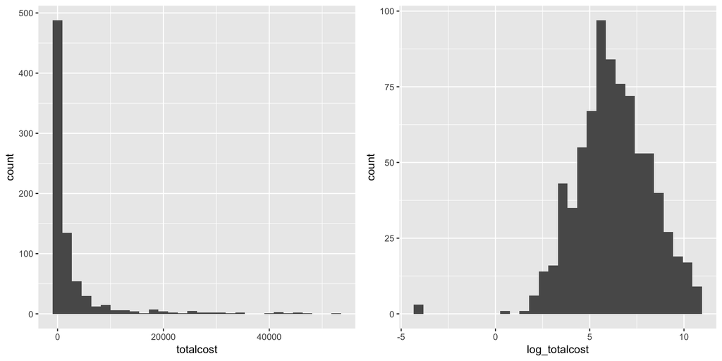

```r
tc_hist + tc_trans_hist
```

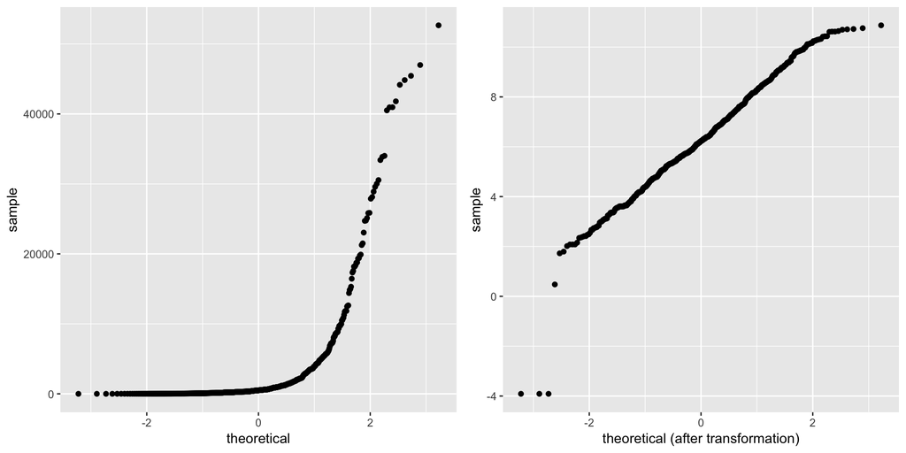

```r
tc_qq + tc_trans_qq
```

**Comments**

After transformation, we can see the distribution of `log_totalcost` is approximate normal distribution. Therefore, transformation is needed.

#### c) Create a new variable called ‘comp_bin’ by dichotomizing ‘complications’: 0 if no complications, and 1 otherwise.

```r
hd_nv = totalcost_trans %>%
  mutate(comp_bin = ifelse(complications == 0, 0, 1))
```

#### d) Based on our decision in part b), fit a simple linear regression (SLR) between the original or transformed ‘total cost’ and predictor ‘ERvisits’. This includes a scatterplot and results of the regression, with appropriate comments on significance and interpretation of the slope.

**Fit Simple Linear Model**

We transformed $Y_{i}$ to $logY_{i}$.

Then, the regression model becomes $logY_{i} = \beta_0^* + \beta_{1}X_{i} + \epsilon_{i}^*$

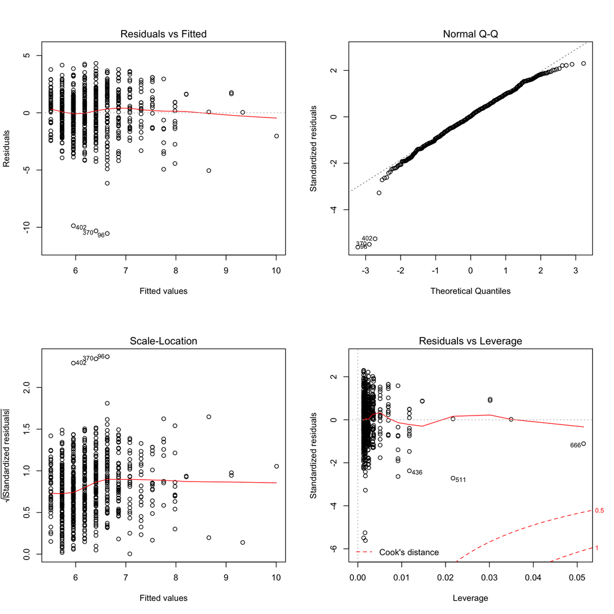

```r
# simple linear regression after transformation
fit = lm(log_totalcost ~ ERvisits, data = totalcost_trans)
par(mfrow=c(2,2))
plot(fit)
```

```r
# analyze the result
summary(fit)
```

```
##
## Call:
## lm(formula = log_totalcost ~ ERvisits, data = totalcost_trans)
##
## Residuals:
##      Min       1Q   Median       3Q      Max
## -10.5418  -1.1041   0.0505   1.3027   4.3197
##
## Coefficients:
##             Estimate Std. Error t value Pr(>|t|)
## (Intercept)   5.5040     0.1098  50.143   <2e-16 ***
## ERvisits      0.2252     0.0254   8.866   <2e-16 ***
## ---
## Signif. codes:  0 '***' 0.001 '**' 0.01 '*' 0.05 '.' 0.1 ' ' 1
##
## Residual standard error: 1.879 on 786 degrees of freedom
## Multiple R-squared:  0.09091,    Adjusted R-squared:  0.08975
## F-statistic:  78.6 on 1 and 786 DF,  p-value: < 2.2e-16
```

```r
glance(fit)$sigma
```

```
## [1] 1.879166
```

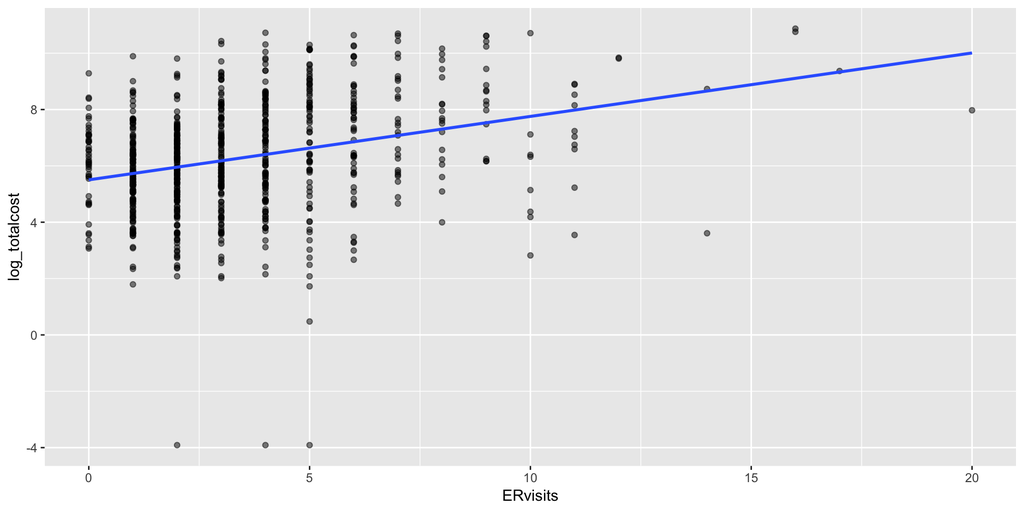

```r
# scatter plot
totalcost_trans %>%
  ggplot(aes(x = ERvisits, y = log_totalcost)) +
  geom_point(alpha = .5) +
  geom_smooth(method = "lm", se = FALSE)
```

From the table above,

$\hat{\beta_0^*} = 5.504, \hat{\beta_{1}} = 0.225$

The estimate regression model is

$\hat{logY_{i}} = 5.504 + 0.225X_{i}$

#### e) Fit a multiple linear regression (MLR) with ‘comp_bin’ and ‘ERvisits’ as predictors.

#### i) Test if ‘comp_bin’ is an effect modifier of the relationship between ‘total cost’ and ‘ERvisits’. Comment.

Make a plot of regression model with variables `ERvisits` and `comp_bin`.

**multi linear regression**

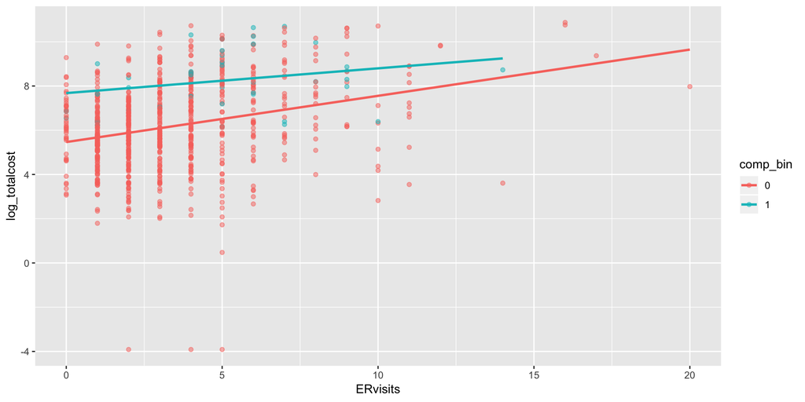

```r
hd_nv %>%
  mutate(comp_bin, comp_bin = as.factor(comp_bin)) %>%
  ggplot(aes(x = ERvisits, y = log_totalcost, color = comp_bin)) +
  geom_point(alpha = .5) +
  geom_smooth(method = "lm", se = FALSE)
```

**Comment**

From the plot above, the blue line and the red line are not parallel, which means that `comp_bin` is an effect modifier of the relationship between `totalcost` and `ERvisits`.

The effect of `comp_bin` and the effect of `ERvisits` are dependent on one another. They do not act independently on `totalcost`.

#### ii) Test if ‘comp_bin’ is a confounder of the relationship between ‘total cost’ and ‘ERvisits’. Comment.

From question d), we got the SLR model of `log_totalcost` and `ERvisits`, which is $\hat{logY_{i}} = 5.504 + 0.225X_{i}$

Let compute the parameter estimate for which adjust for `ERvisits` which adjusts for potential confounder `comp_bin`.

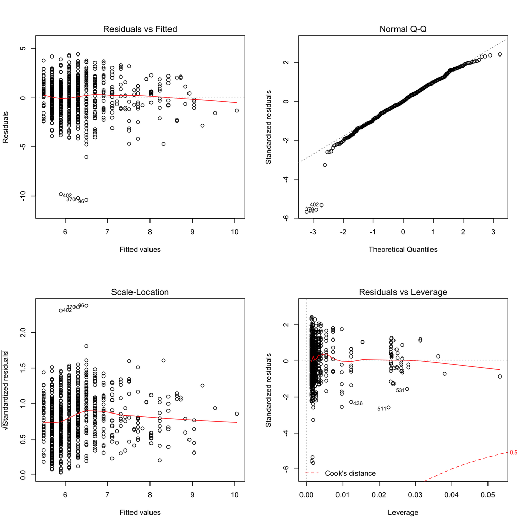

```r
fit_multi = lm(log_totalcost ~ ERvisits + comp_bin, data = hd_nv)


par(mfrow=c(2,2))
plot(fit_multi)
```

```r
vif(fit_multi)
```

```
## ERvisits comp_bin
## 1.023658 1.023658
```

```r
summary(fit)
```

```
##
## Call:
## lm(formula = log_totalcost ~ ERvisits, data = totalcost_trans)
##
## Residuals:
##      Min       1Q   Median       3Q      Max
## -10.5418  -1.1041   0.0505   1.3027   4.3197
##
## Coefficients:
##             Estimate Std. Error t value Pr(>|t|)
## (Intercept)   5.5040     0.1098  50.143   <2e-16 ***
## ERvisits      0.2252     0.0254   8.866   <2e-16 ***
## ---
## Signif. codes:  0 '***' 0.001 '**' 0.01 '*' 0.05 '.' 0.1 ' ' 1
##
## Residual standard error: 1.879 on 786 degrees of freedom
## Multiple R-squared:  0.09091,    Adjusted R-squared:  0.08975
## F-statistic:  78.6 on 1 and 786 DF,  p-value: < 2.2e-16
```

```r
summary(fit_multi)
```

```
##
## Call:
## lm(formula = log_totalcost ~ ERvisits + comp_bin, data = hd_nv)
##
## Residuals:
##      Min       1Q   Median       3Q      Max
## -10.4117  -1.0591   0.0138   1.2077   4.4271
##
## Coefficients:
##             Estimate Std. Error t value Pr(>|t|)
## (Intercept)  5.48721    0.10749  51.047  < 2e-16 ***
## ERvisits     0.20249    0.02516   8.050 3.07e-15 ***
## comp_bin     1.73051    0.29192   5.928 4.59e-09 ***
## ---
## Signif. codes:  0 '***' 0.001 '**' 0.01 '*' 0.05 '.' 0.1 ' ' 1
##
## Residual standard error: 1.84 on 785 degrees of freedom
## Multiple R-squared:  0.1299, Adjusted R-squared:  0.1276
## F-statistic: 58.58 on 2 and 785 DF,  p-value: < 2.2e-16
```

```r
(0.225 - 0.203)/0.225
```

```
## [1] 0.09777778
```

Then, calculate the percentage change in the parameter estimate

**Conclusion**

From the $VIF(\hat\beta_{i})$ of `ERvisits` and `comp_bin`, we can conclude that the multicollinearity is low.

#### iii) Decide if ‘comp_bin’ should be included along with ‘ERvisits. Why or why not?

**Answer**

Based on the investigation aboved, `comp_bin` an effect modifier of the relationship between `totalcost` and `ERvisits`. Compared to a patient wihout complication (`comp_bin` = `0`), the change of total cost for a patient with complication (`comp_bin` = `1`) are not so sensitive affected by ERvisits, as it’s resonable to think that the cost for these patients is already higher than patients without complications.

Also, `comp_bin` is not presented as a problematic confounder for `ERvisits`.

Therefore, we need to include `comp_bin` along with `ERvisits`.

#### f) Use your choice of model in part e) and add additional covariates (age, gender, and duration of treatment).

#### i) Fit a MLR, show the regression results and comment.

```r
# Fit a linear regression with comp_bin
fit_multi = lm(log_totalcost ~ ERvisits + comp_bin, data = hd_nv)
summary(fit_multi)
```

```
##
## Call:
## lm(formula = log_totalcost ~ ERvisits + comp_bin, data = hd_nv)
##
## Residuals:
##      Min       1Q   Median       3Q      Max
## -10.4117  -1.0591   0.0138   1.2077   4.4271
##
## Coefficients:
##             Estimate Std. Error t value Pr(>|t|)
## (Intercept)  5.48721    0.10749  51.047  < 2e-16 ***
## ERvisits     0.20249    0.02516   8.050 3.07e-15 ***
## comp_bin     1.73051    0.29192   5.928 4.59e-09 ***
## ---
## Signif. codes:  0 '***' 0.001 '**' 0.01 '*' 0.05 '.' 0.1 ' ' 1
##
## Residual standard error: 1.84 on 785 degrees of freedom
## Multiple R-squared:  0.1299, Adjusted R-squared:  0.1276
## F-statistic: 58.58 on 2 and 785 DF,  p-value: < 2.2e-16
```

```r
# Fit a linear regression with comp_bin and all additional covariates
fit_multiadd = lm(log_totalcost ~ ERvisits + comp_bin + duration + age + gender, data = hd_nv)
summary(fit_multiadd)
```

```
##
## Call:
## lm(formula = log_totalcost ~ ERvisits + comp_bin + duration +
##     age + gender, data = hd_nv)
##
## Residuals:
##     Min      1Q  Median      3Q     Max
## -9.2680 -1.0141 -0.0896  0.9748  4.3489
##
## Coefficients:
##               Estimate Std. Error t value Pr(>|t|)
## (Intercept)  5.8606350  0.5340763  10.973  < 2e-16 ***
## ERvisits     0.1738326  0.0236205   7.359 4.68e-13 ***
## comp_bin     1.5234306  0.2704754   5.632 2.48e-08 ***
## duration     0.0059348  0.0005115  11.602  < 2e-16 ***
## age         -0.0200116  0.0090769  -2.205   0.0278 *
## gender      -0.2731592  0.1451323  -1.882   0.0602 .
## ---
## Signif. codes:  0 '***' 0.001 '**' 0.01 '*' 0.05 '.' 0.1 ' ' 1
##
## Residual standard error: 1.699 on 782 degrees of freedom
## Multiple R-squared:  0.2605, Adjusted R-squared:  0.2557
## F-statistic: 55.08 on 5 and 782 DF,  p-value: < 2.2e-16
```

```r
# Fit a linear regression with comp_bin and duration
fit_multi_d = lm(log_totalcost ~ ERvisits + comp_bin + duration, data = hd_nv)
summary(fit_multi_d)
```

```
##
## Call:
## lm(formula = log_totalcost ~ ERvisits + comp_bin + duration,
##     data = hd_nv)
##
## Residuals:
##     Min      1Q  Median      3Q     Max
## -9.4164 -1.0886 -0.0896  0.9880  4.6834
##
## Coefficients:
##              Estimate Std. Error t value Pr(>|t|)
## (Intercept) 4.6722123  0.1228387  38.035  < 2e-16 ***
## ERvisits    0.1664235  0.0235423   7.069 3.45e-12 ***
## comp_bin    1.5570549  0.2711287   5.743 1.33e-08 ***
## duration    0.0057795  0.0005091  11.353  < 2e-16 ***
## ---
## Signif. codes:  0 '***' 0.001 '**' 0.01 '*' 0.05 '.' 0.1 ' ' 1
##
## Residual standard error: 1.706 on 784 degrees of freedom
## Multiple R-squared:  0.2527, Adjusted R-squared:  0.2499
## F-statistic: 88.38 on 3 and 784 DF,  p-value: < 2.2e-16
```

**Comment**

From the results above, a small p-value indicates a strong evidence to show that the coefficient estimators of `ERvisits`, `comp_bin` and `duration` are not zero. By looking at the `Adjusted R-squared`, adding `duration` actually improves the model.

#### ii) Compare the SLR and MLR models. Which model would you use to address the investigator’s objective and why?

Compare the models

```r
anova(fit_multiadd)
```

```
## Analysis of Variance Table
##
## Response: log_totalcost
##            Df  Sum Sq Mean Sq  F value    Pr(>F)
## ERvisits    1  277.56  277.56  96.1282 < 2.2e-16 ***
## comp_bin    1  118.93  118.93  41.1900 2.393e-10 ***
## duration    1  375.10  375.10 129.9108 < 2.2e-16 ***
## age         1   13.42   13.42   4.6468   0.03142 *
## gender      1   10.23   10.23   3.5424   0.06019 .
## Residuals 782 2257.90    2.89
## ---
## Signif. codes:  0 '***' 0.001 '**' 0.01 '*' 0.05 '.' 0.1 ' ' 1
```

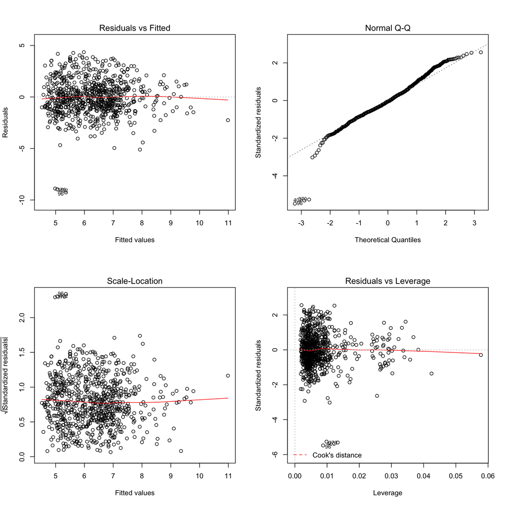

```r
par(mfrow=c(2,2))
plot(fit_multiadd)
```

**Answer**

I would use the MLR model with `ERvisits`, `comp_bin`, and `duration`.

First, the `F value` for `ERvisits`, `comp_bin` and `duration` are the highest three among all.

Second, the p-value is low enough, which indicates coefficient estimators are not equal to zero. Third, the *Residuals vs Fitted* plot is reasonable with residual values bounce around 0.

### Problem 3

A hospital administrator wishes to test the relationship between ‘patient’s satisfaction’ (Y) and ‘age’, ‘severity of illness’, and ‘anxiety level’ (data ‘PatSatisfaction.xlsx’). The administrator randomly selected 46 patients, collected the data, and asked for your help with the analysis.

#### a) Create a correlation matrix and interpret your initial findings.

```r
patsat = readxl::read_excel("./data/PatSatisfaction.xlsx") %>%
  janitor::clean_names() %>%
  mutate(satisfaction = safisfaction) %>%
  select(satisfaction, age, severity, anxiety)

cor(patsat)
```

```
##              satisfaction        age   severity    anxiety
## satisfaction    1.0000000 -0.7867555 -0.6029417 -0.6445910
## age            -0.7867555  1.0000000  0.5679505  0.5696775
## severity       -0.6029417  0.5679505  1.0000000  0.6705287
## anxiety        -0.6445910  0.5696775  0.6705287  1.0000000
```

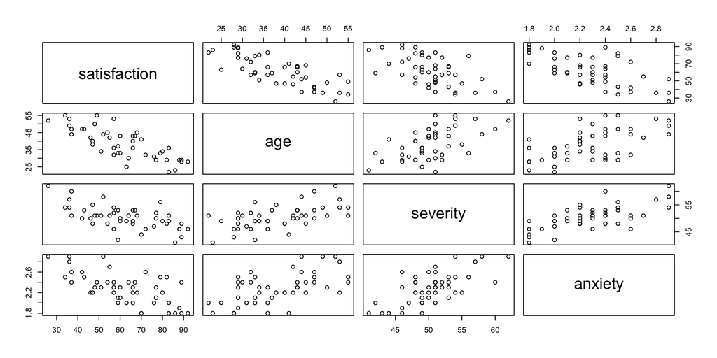

```r
pairs(patsat)
```

**Initial Findings**

The following variables have positive correlation:

`Severity` and `Age`

`Anxiety` and `Age`

`Severity` and `Anxiety`.

`Age`, `Severity` and `Anxiety` all have negative correlation with `Satisfaction`.

#### b) Fit a multiple regression model and test whether there is a regression relation. State the hypotheses, decision rule and conclusion.

```r
patsat_fit = lm(satisfaction ~ age + severity + anxiety, data = patsat)

summary(patsat_fit)
```

```
##
## Call:
## lm(formula = satisfaction ~ age + severity + anxiety, data = patsat)
##
## Residuals:
##      Min       1Q   Median       3Q      Max
## -18.3524  -6.4230   0.5196   8.3715  17.1601
##
## Coefficients:
##             Estimate Std. Error t value Pr(>|t|)
## (Intercept) 158.4913    18.1259   8.744 5.26e-11 ***
## age          -1.1416     0.2148  -5.315 3.81e-06 ***
## severity     -0.4420     0.4920  -0.898   0.3741
## anxiety     -13.4702     7.0997  -1.897   0.0647 .
## ---
## Signif. codes:  0 '***' 0.001 '**' 0.01 '*' 0.05 '.' 0.1 ' ' 1
##
## Residual standard error: 10.06 on 42 degrees of freedom
## Multiple R-squared:  0.6822, Adjusted R-squared:  0.6595
## F-statistic: 30.05 on 3 and 42 DF,  p-value: 1.542e-10
```

3. Show the regression results for all estimated coefficients with 95% CIs. Interpret the coefficient and 95% CI associated with ‘severity of illness’. (5p)
4. Obtain an interval estimate for a new patient’s satisfaction when Age=35, Severity=42, Anxiety=2.1. Interpret the interval. (2p)
5. Test whether ‘anxiety level’ can be dropped from the regression model, given the other two covariates are retained. State the hypotheses, decision rule and conclusion. (3p)